# Homework 3, due Sunday 2/11, 11.59pm

- Show All Code
- Hide All Code
- View Source

Author

DATASCI/STATS 531, Liangqi Tang

This homework is a small data analysis project designed as preparation for the midterm project. In particular, you are required to write your report using Rmd format, which is required for the midterm and final projects. Consequently you should submit two files, an Rmd file and the HTML document you obtain by compiling it. The Rmd file should be written so that the grader can run it, and therefore the data should be read from the homework website rather than from a local directory. The grader will not necessarily recompile the Rmd, but if they do then it should reproduce the HTML. If technical difficulties arise with learning to use Rmd format, please consult your peers, piazza, the GSI or myself.

Most of you will find that editing the Rmd file in Rstudio may be the simplest solution. Also, the source files for this homework and all the notes are on the class GitHub site: if you see anything in the notes that you’d like to reproduce, you can take advantage of that. Opening the file hw03.Rmd in Rstudio and editing it to produce your solution is one way to proceed. You may also like to browse http://www.stat.cmu.edu/~cshalizi/rmarkdown/.

You will need to know some Latex to write equations in Rmarkdown. Many tutorials exist online, e.g. http://www.latex-tutorial.com/tutorials. One legitimate approach is to identify equations in the notes that you would like to modify, and then dig out the source code from the course github repository. If you look at code from the slides, it will be in Rnw format not Rmd format: both methods combine Latex and R in similar ways, and the main practical difference is the symbols used to separate code chunks from text.

Your report should contain a reference section listing sources. The grader should be able to clearly identify where the sources were used, for example using reference numbers in the text. Anything and anyone consulted while you are working on the homework counts as a source and should be credited. The homework will be graded following the posted rubric.

**Question 3.1**. Try out some of the ARMA techniques studied in class on the Ann Arbor January Low temperature time series that we saw in Chapter 1 of the notes. Write a report as an Rmd file and submit this file on the class Canvas site. This is an open-ended assignment, but you’re only expected to do what you can in a reasonable amount of time. Some advice follows.

1. You can read in the data with

```r
x <- read.table(file="http://ionides.github.io/531w24/01/ann_arbor_weather.csv",header=TRUE)
plot(Low~Year,data=x,type="l")
```

2. Your report should involve model equations and hypotheses, and should define the notation used. Please be careful to distinguish between symbols representing random variables (usually using capital letters) and numbers. You are welcome to follow the notation in the course notes, and if you deviate from this notation it is especially necessary to define the notation that you choose.
3. You are advised to try a few things from the notes, spot something that catches your attention, and try a few more things to investigate it. Write up what you found, and you’re finished!
4. When writing up your homework report, you must choose which pieces of R code to include in the HTML document. To tell Rmarkdown not to include the R code in the HTML document, use the `echo=FALSE` chunk option, e.g.,

```
only the output of this code chunk will be printed
```

You should only display the code in the HTML document if you think that, in your context, the helpfulness of showing the code outweighs the extra burden on the reader, since the reader can work through the Rmd source file if necessary. For your homework report, it is helpful to show more code than you would in a project report. A suitable balance might be similar to the style of the course notes.

5. When you have got everything you can out of the Ann Arbor January Low temperature time series, consider it in the context of the global mean annual temperature time series on the class github site:

```r
global <- read.table(file="http://ionides.github.io/531w24/hw03/Global_Temperature.txt",header=TRUE)
plot(Annual~Year,data=global,type="l")
```

**Answer**:

**Besides ARMA models, I first tried simple regression model and random walk model to study the time series, get some intuitions and deepen my understanding of it.**

# plot and observe

First I load the data and plot the data using the code provided above (cite: the Homework3 html file, Question3.1 1.):

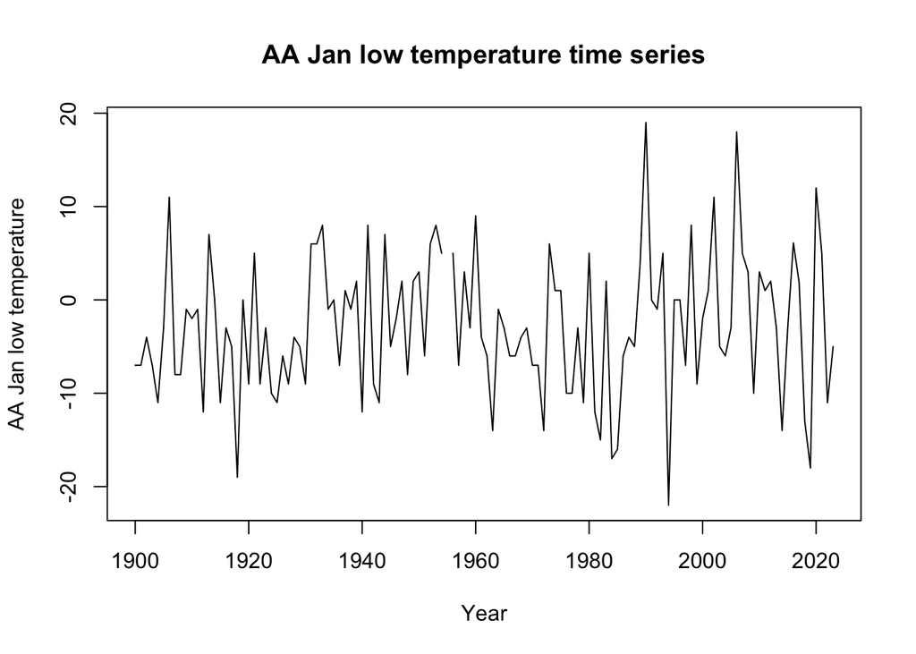

```r
Jan <- read.table(file="http://ionides.github.io/531w24/01/ann_arbor_weather.csv",header=TRUE)
plot(Low~Year,data=Jan,type="l", ylab = "AA Jan low temperature", main = "AA Jan low temperature time series")
```

It’s obvious that the time series has a trend of increasing on the first look. So firstly, I want to try a Linear Regression model and **suppose that there is no autocorrelation in this time series and they can be viewed as iid samples**.

# models for January

## 1. Linear Trend

### definition

- Define $Y_t$ as Ann Arbor January Low temperature at time $t$.
- Define $T$ as time
- Define $y_t$ as the specific numbers of $Y_t$.
- Define $w_t$ as the residues of the regression

### assumption/hypothesis

- 1. The regression model is of linear form
- 2. the residues $w_t \overset{iid}{\sim} N(0, \sigma^2)$ (cite: Julian J Faraway - Linear Models with R - Taylor & Francis 2014, chapter 1: Introduction, 2.2 Matrix Representation)

### model equation

then the mean value expression of the linear regression model can be written as: (cite: [wikipedia, OLS](https://en.wikipedia.org/wiki/Ordinary_least_squares#))

$$Y_t = \beta_0 + \beta_1 T + w_t$$

### model fitting

(cite: Shumway, R.H., and Stoffer, D.S., 2017, Chapter 2, Example 2.1)

```r
# fit the model
summary(fit <- lm(Low ~ Year, data = Jan))
```

```
Call:
lm(formula = Low ~ Year, data = Jan)

Residuals:
     Min       1Q   Median       3Q      Max
-19.7851  -4.5957  -0.3117   4.9309  21.2907

Coefficients:
             Estimate Std. Error t value Pr(>|t|)
(Intercept) -39.96878   36.94477  -1.082    0.281
Year          0.01893    0.01883   1.005    0.317

Residual standard error: 7.505 on 121 degrees of freedom
  (1 observation deleted due to missingness)
Multiple R-squared:  0.008285,  Adjusted R-squared:  8.941e-05
F-statistic: 1.011 on 1 and 121 DF,  p-value: 0.3167
```

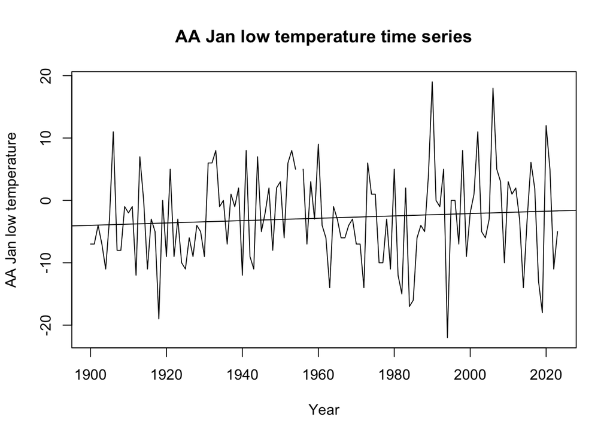

```r
# plot the data and regression line
plot(Low~Year,data=Jan,type="l", ylab = "AA Jan low temperature", main = "AA Jan low temperature time series")
abline(fit)
```

### discussion

- pros: The simple OLS (ordinary least square) model can picture that the time $t$ has an effect on the temperature. Clearly, from the summary of the regression model we can find that the coefficient of $t$ is positive, which is consistent with our observation. And the regression line can show the general trend of the time series.
- cons: The coefficent of Year is not significant here. So the result is not convincing. Besides, OLS model is only reasonable and appropriate under very strong assumption, which is often unrealistic with the data from real life.

Although we do not diagnosed the model here, we will continue discussing some time series models with autocorrelation and will be against the model assumption, in which we omit the autocorrelation.

Now, with closer observation on the time series, we can find that the data points seems to be around the trend randomly. To see the it more clearly, we do the following plots: (cite: Shumway, R.H., and Stoffer, D.S., 2017, Chapter 2, Example 2.4)

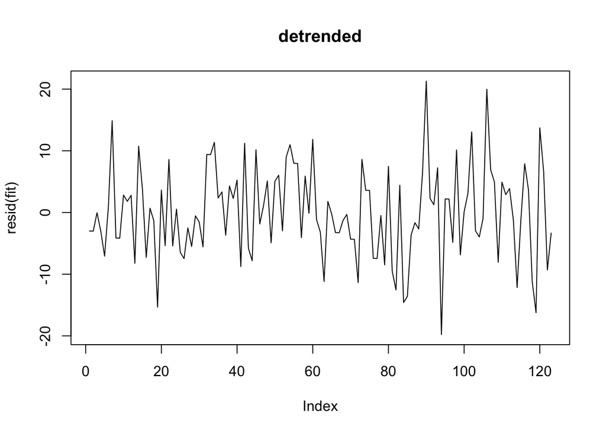

```r
plot(resid(fit), type = "l", main = "detrended")
```

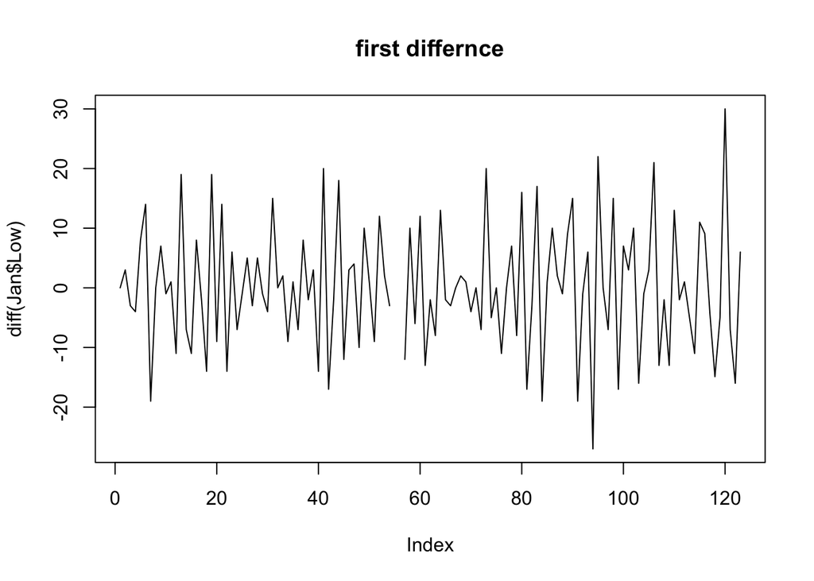

```r
plot(diff(Jan$Low), type = "l", main = "first differnce")
```

This prompts us that maybe after detrending the time series, it will be stationary. i.e., we can try *trend stationary*(cite: Shumway, R.H., and Stoffer, D.S., 2017, Chapter 2, section 2.2) on the time series. *Random walk with drift* is a good choice.

## 2. Random walk with drift

### definition

- Define $Y_t$ as Ann Arbor January Low temperature at time $t$.
- Define $y_t$ as the specific numbers of $Y_t$.
- Define $w_t$ as the Gaussian white noise $N(0, \sigma^2)$.
- Define $\sigma$ as the drift.

### assumption/hypothesis

The time series is a trend stationary time series and it’s a very simple form: random walk with drift. So we include the autocorrelation of the series into the model but we only consider the first difference.

### model equation

(cite: Shumway, R.H., and Stoffer, D.S., 2017, Chapter 2, (2.26))

$$Y_t = \sigma + Y_{t-1} + w_t$$

### model fitting

(cite: [Notes on random walk model](https://people.duke.edu/~rnau/Notes_on_the_random_walk_model--Robert_Nau.pdf)) Based on the model equation, we just need to compute the $\sigma$ using first difference.

```r
sigma <- mean(diff(Jan$Low), na.rm = TRUE)
sigma2 <- var(diff(Jan$Low), na.rm = TRUE)
sigma
```

```
[1] 0.01652893
```

```r
sigma2
```

```
[1] 112.2869
```

Thus the model estimation is:

$$y_t = 0.016 + y_{t-1} + N(0, 112)$$

We can try to simulate the model and compare the result with real data:

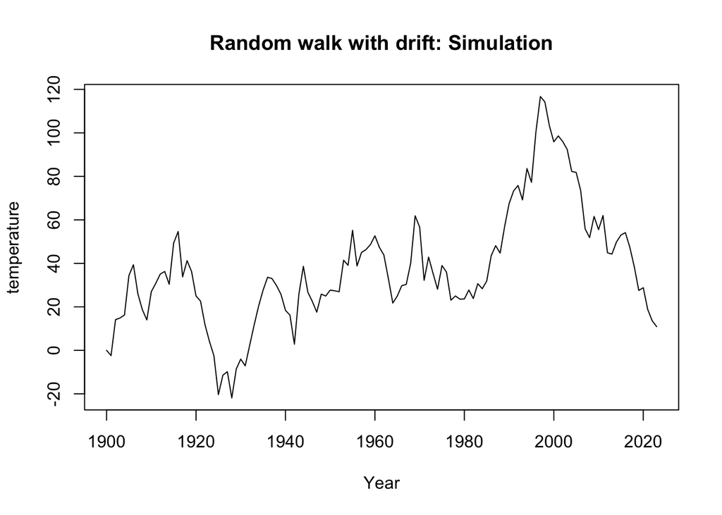

```r
set.seed(123)
N <- length(Jan$Low)
w <- rnorm(N, mean = 0, sd = sd(diff(Jan$Low), na.rm = TRUE))
y <- numeric(N)
for (n in 2:N) {
  y[n] <- y[n-1] + sigma + w[n]
}
plot(Jan$Year, y, type = "l", xlab = "Year", ylab = "temperature", main = "Random walk with drift: Simulation")
```

### discussion

We can check and evaluate our Random walk with drift model compared with detrended model (by OLS) using acf plots below:

(cite: Shumway, R.H., and Stoffer, D.S., 2017, Chapter 2, Example 2.5, R code)

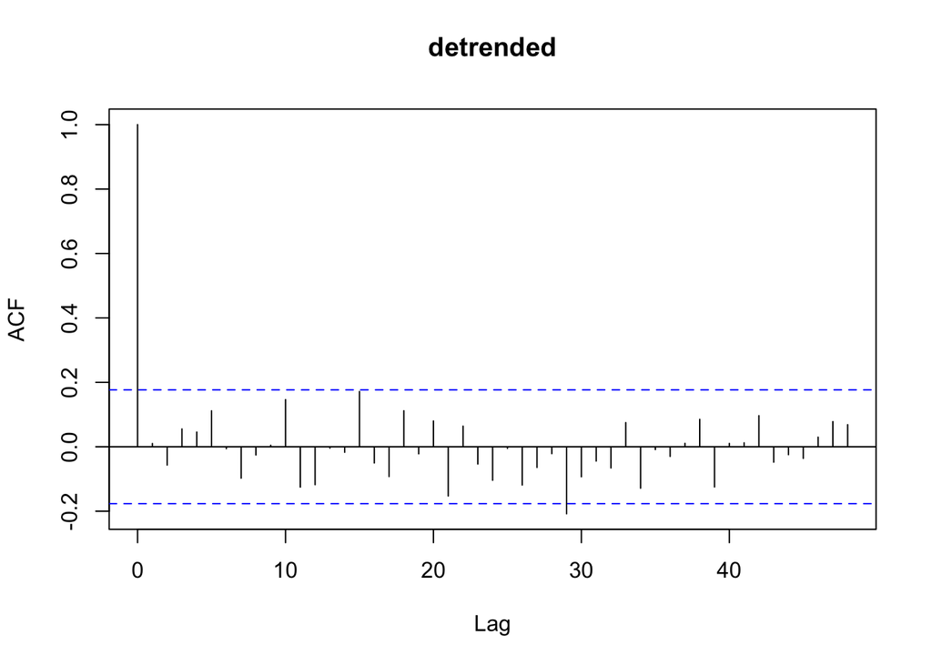

```r
acf(resid(fit)[!is.na(resid(fit))], 48, main = "detrended")
```

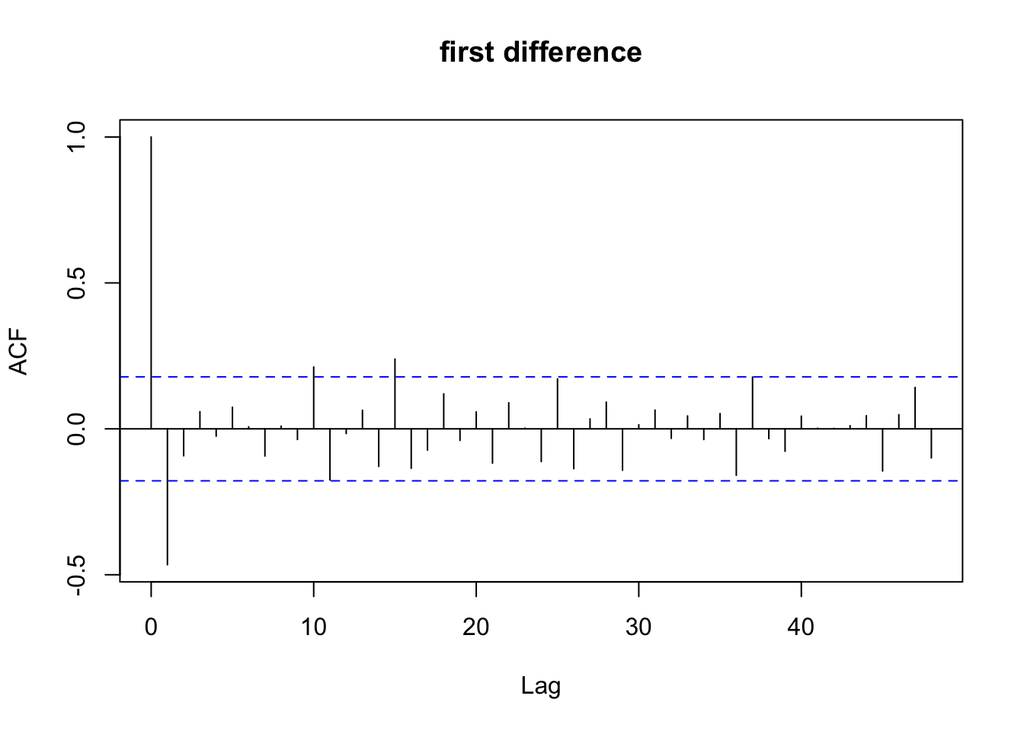

```r
acf(diff(Jan$Low)[!is.na(diff(Jan$Low))], 48, main = "first difference")
```

Through the simulation result, it’s not realistic. And compare the acf plots we find that random walk with drift does not improve the result of linear regression. Perhaps the reason that the random walk with drift model is not appropriate here is that the first difference of the Low temperature has very large variance, which is not suitable to estimate with Gaussian white noise.

Maybe there is much more about the autocorrelation and stationarity of the time series. We can plot the scatterplot matrix of the data:

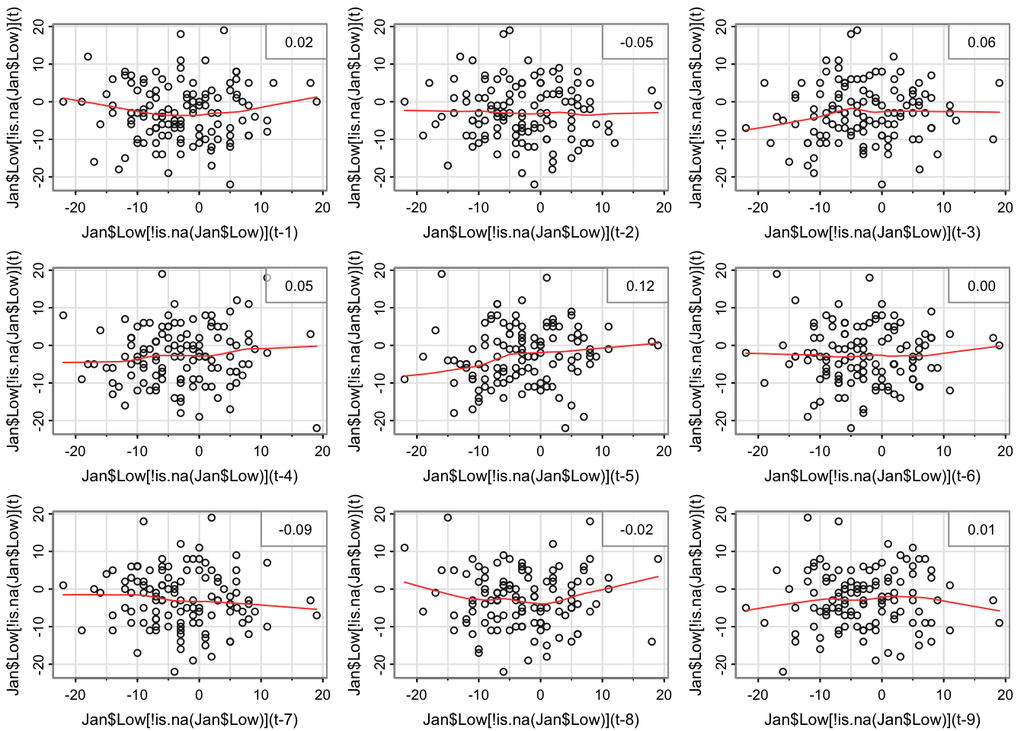

```r
library(astsa)
lag1.plot(Jan$Low[!is.na(Jan$Low)], 9)
```

This prompts us that we need more comprehensive models to better depict the characters of the time series. Thus here I tried some ARIMA models to fit the time series.

## 3. ARIMA

### definition

- Define $Y_t$ as Ann Arbor January Low temperature at time $t$.
- Define $y_t$ as the specific numbers of $Y_t$.
- Define $\epsilon_t$ as Gaussian white noise at time $t$, i.e. $\epsilon_n \overset{iid}{\sim}N(0. \sigma^2)$.
- Define $\mu$ as the expectation value of $Y_t$.
- Define $\phi(x) = 1- \phi_1x - \phi_2 x^2 - \cdots - \phi_px^p$.
- Define $\psi(x) = 1+ \psi_1x + \psi_2 x^2 + \cdots + \psi_qx^q$.
- Define $B$ as the backshift operater, $By_t = y_{t-1}$.
- Define $\phi_i$ as the coefficient of $y_{t-i}$.
- Define $\psi_j$ as the coefficient of $\epsilon_{t-j}$

### assumption/hypothesis

- The model is stationary
- The model is causal
- The model is invertible

(cite:[Autoregressive Moving-average Model](https://en.wikipedia.org/wiki/Autoregressive_moving-average_model#ARMA_model))

### model equation

ARMA($p$,$q$):

$$Y_t = \phi_1 Y_{t-1}+ \phi_2 Y_{t-2} + \cdots + \phi_p Y_{t-p} + \epsilon_t + \psi_1\epsilon_{t-1} + \cdots + \psi_q \epsilon_{t-q} + \mu(1-\phi_1 -\cdots - \phi_p)$$

or equivalently (cite: [Lecture Slides 5, page 28](https://ionides.github.io/531w24/05/slides.pdf)):

$$\phi(B)(Y_t - \mu) = \psi(B)\epsilon_t$$

### model fitting

Basicly, I tried to choose $p$ and $q$ based on the AIC values for a range of different choices of $p$ and $q$ like the notes did: (cite: [[Lecture Slides 5, page 29](https://ionides.github.io/531w24/05/slides.pdf)], debug: [Stackoverflow](https://stackoverflow.com/questions/7233288/non-stationary-seasonal-ar-part-from-css-error-in-r))

```r
temp <- Jan$Low[!is.na(Jan$Low)]
aic_table <- function(data,P,Q){
table <- matrix(NA,(P+1),(Q+1))
for(p in 0:P) {
for(q in 0:Q) {
table[p+1,q+1] <- tryCatch( {arima(data,order=c(p,0,q), method = "ML")$aic},
                            error = function(e){return(NA)})
}
}
dimnames(table) <- list(paste("AR",0:P, sep=""),
paste("MA",0:Q,sep=""))
table
}
temp_aic_table <- aic_table(temp,4,4)
require(knitr)
kable(temp_aic_table,digits=2)
```

|  | MA0 | MA1 | MA2 | MA3 | MA4 |
| --- | --- | --- | --- | --- | --- |
| AR0 | 847.90 | 849.85 | 851.57 | 852.93 | 854.41 |
| AR1 | 849.86 | 851.47 | 853.27 | 854.06 | 855.96 |
| AR2 | 851.58 | 853.24 | 848.35 | 851.42 | 851.37 |
| AR3 | 853.06 | 854.37 | 849.64 | 857.82 | 855.22 |
| AR4 | 854.78 | 856.23 | 858.37 | 855.22 | 853.93 |

Based on the table, I finally choose the ARMA(0,0) (Thus it will just be a white noise), ARMA(1,0), ARMA(0,1) and ARMA(2,2) since they have the smallest AIC value. Now I output the result of the model: (cite: [Lecture Slides 1, page 20](https://ionides.github.io/531w24/01/slides.pdf))

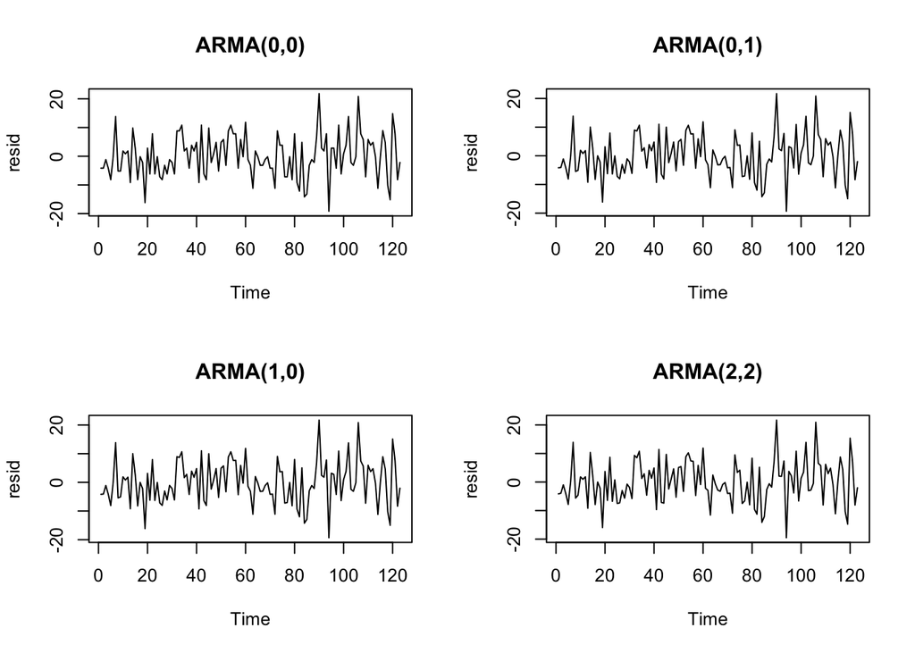

```r
arima00 <- arima(temp, order = c(0,0,0))
arima10 <- arima(temp, order = c(1,0,0))
arima01 <- arima(temp, order = c(0,0,1))
arima22 <- arima(temp, order = c(2,0,2))

# plot the residues
par(mfrow = c(2,2))
plot(arima00$resid, main = "ARMA(0,0)", xlab = "Time", ylab = "resid")
plot(arima01$resid, main = "ARMA(0,1)", xlab = "Time", ylab = "resid")
plot(arima10$resid, main = "ARMA(1,0)", xlab = "Time", ylab = "resid")
plot(arima22$resid, main = "ARMA(2,2)", xlab = "Time", ylab = "resid")
```

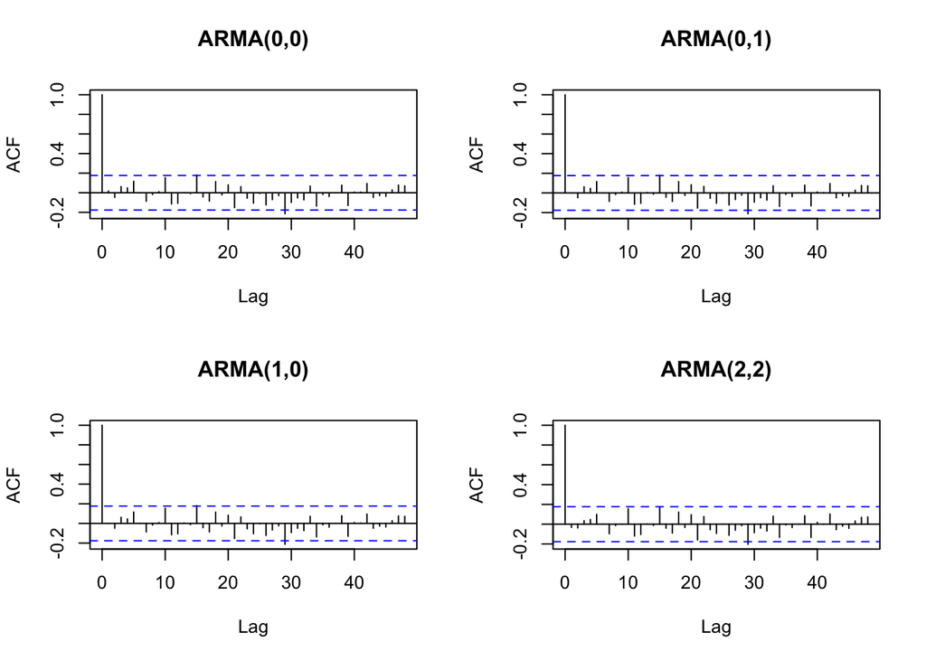

```r
# plot the acf of the models
par(mfrow = c(2,2))
acf(arima00$resid, 48, main = "ARMA(0,0)")
acf(arima01$resid, 48, main = "ARMA(0,1)")
acf(arima10$resid, 48, main = "ARMA(1,0)")
acf(arima22$resid, 48, main = "ARMA(2,2)")
```

### discussion

- pros: Basically, the acfs lie in the confidence interval.
- cons: However, since the AIC of all the models here are quite large, it seems that they all do not fit very well. Besides, the selected ARMA models are not significantly better than white noises, which means that maybe ARMA models are not appropriate here.

To further study the ARMA models on this data set, here I select AMRA(2,2) to do the simulation and compare it with our original data:

Firstly, show the estimation results:

```r
# show the result
arima22
```

```
Call:
arima(x = temp, order = c(2, 0, 2))

Coefficients:
         ar1     ar2      ma1      ma2  intercept
      0.1698  0.5476  -0.1166  -0.5686    -2.8400
s.e.  0.5740  0.4312   0.5616   0.4160     0.7475

sigma^2 estimated as 55.64:  log likelihood = -421.7,  aic = 855.39
```

```r
# compute Var(y_t)
var(Jan$Low, na.rm = TRUE)
```

```
[1] 56.32979
```

Next, check if the assumption of causality and invertibility are satisfied: (cite: [Lecture slides 5, page32])

```r
# check AR roots
AR_roots <- polyroot(c(1, -coef(arima22)[c("ar1","ar2")]))
AR_roots
```

```
[1]  1.205179+0i -1.515256+0i
```

```r
# check MA roots
MA_roots <- polyroot(c(1, coef(arima22)[c("ma1","ma2")]))
MA_roots
```

```
[1]  1.227609+0i -1.432622+0i
```

It turns out that all the roots are outside the unit circle on the complex plane, thus the causality and invertibility are verified.

Now we need to compute the $\sigma^2$ which is the variance of the $\epsilon_t$ in this model:

$$\begin {aligned}
y_t &= \phi_1y_{t-1} + \phi_2y_{t-2} + \epsilon_t+\psi_1 \epsilon_{t-1} + \psi_2\epsilon_{t-2} + \text{intercept}\\
\text{Var}(y_t) &= \phi_1^2 \text{Var}(y_{t-1}) + \phi_2^2\text{Var}(y_{t-2}) + (\psi_1^2 + \psi_2^2)\sigma^2\\
\sigma^2 &= \frac{(1-\phi_1^2 -\phi_2^2)\text{Var}(y_t)}{\psi_1^2 + \psi_2^2} = 112.24
\end {aligned}$$

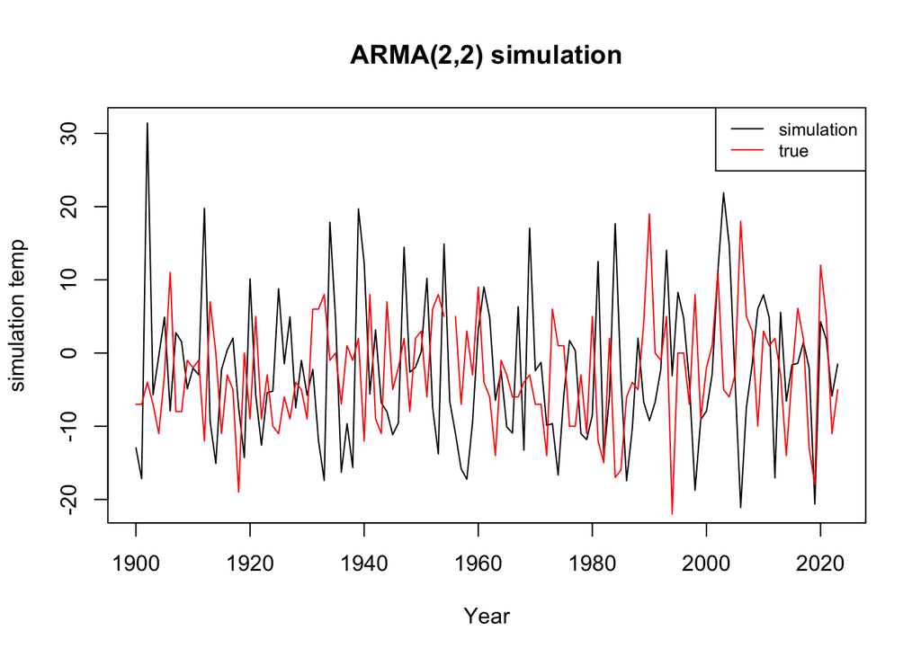

```r
# plot the simulation data
arma22 <- arima.sim(list(ar = c(0.1698, 0.5476), ma = c(-0.1166, -0.5686)), n = length(Jan$Low), sd = sqrt(112.24))
plot(Jan$Year, arma22 - 2.84, type = "l", xlab = "Year", ylab = "simulation temp", main = "ARMA(2,2) simulation")
lines(Jan$Year, Jan$Low, col = "red", type = "l")
legend("topright", legend=c("simulation", "true"),
       col=c("black", "red"), lty = c(1,1), cex=0.8)
```

Compared with original data, the variance of simulation is a little larger than the true data.

# models for global

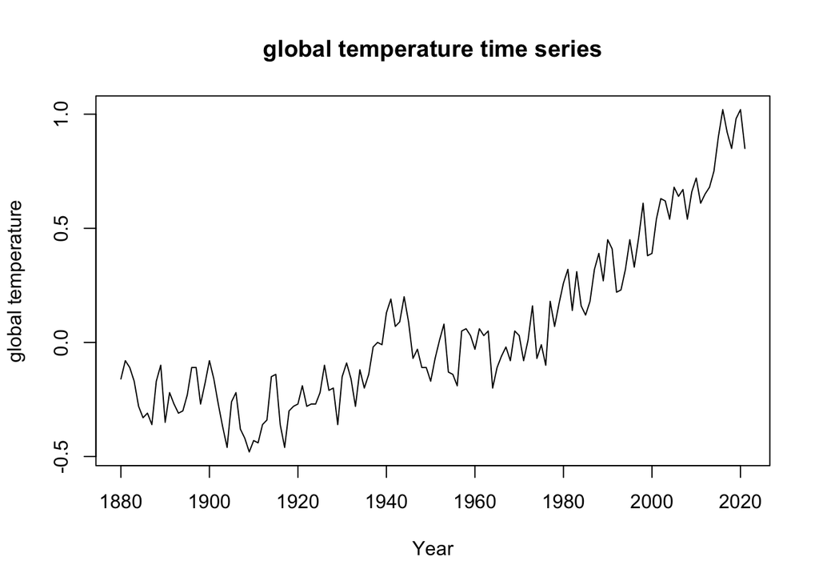

```r
global <- read.table(file="http://ionides.github.io/531w24/hw03/Global_Temperature.txt",header=TRUE)
plot(Annual~Year,data=global,type="l",ylab = "global temperature", main = "global temperature time series")
```

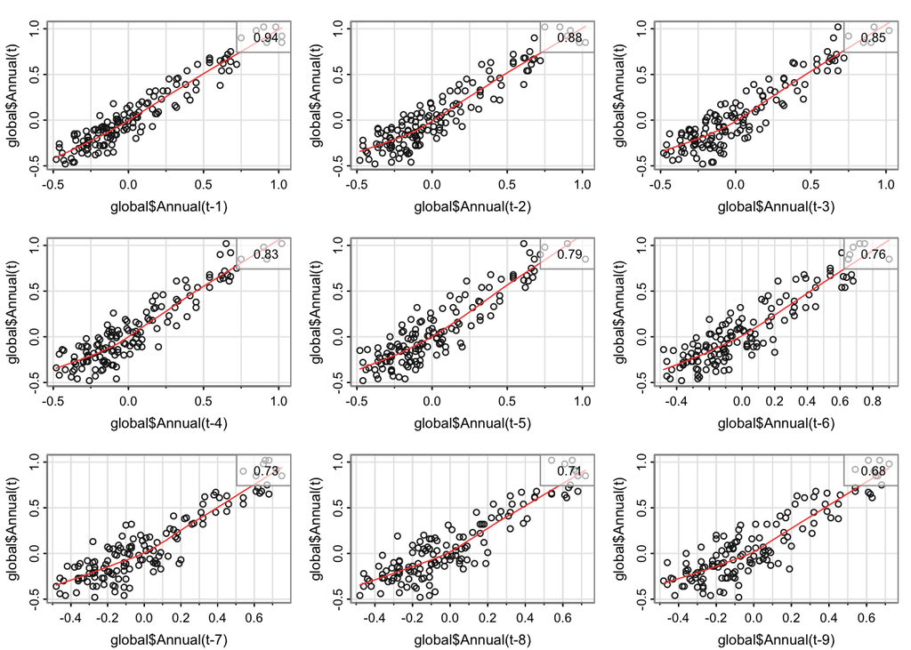

```r
lag1.plot(global$Annual, 9)
```

Basically the definition, hypothesis and model equations are the same.

## 1. Linear Trend

### model fitting

```r
# fit the model
summary(fit <- lm(Annual ~ Year, data = global))
```

```
Call:
lm(formula = Annual ~ Year, data = global)

Residuals:
    Min      1Q  Median      3Q     Max
-0.3594 -0.1347 -0.0344  0.1235  0.4607

Coefficients:
              Estimate Std. Error t value Pr(>|t|)
(Intercept) -1.494e+01  7.155e-01  -20.89   <2e-16 ***
Year         7.690e-03  3.667e-04   20.97   <2e-16 ***
---
Signif. codes:  0 '***' 0.001 '**' 0.01 '*' 0.05 '.' 0.1 ' ' 1

Residual standard error: 0.1791 on 140 degrees of freedom
Multiple R-squared:  0.7585,    Adjusted R-squared:  0.7568
F-statistic: 439.7 on 1 and 140 DF,  p-value: < 2.2e-16
```

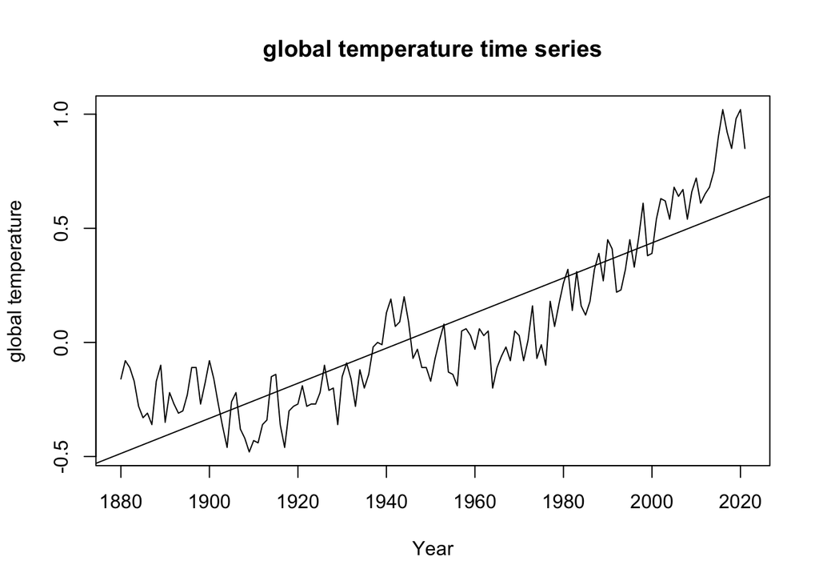

```r
# plot the data and regression line
plot(Annual~Year,data=global,type="l", ylab = "global temperature", main = "global temperature time series")
abline(fit)
```

### discussion

Now the OLS performs better on global data set since the coefficients become significant.

## 2. Random walk with drift

### model fitting

```r
sigma <- mean(diff(global$Annual), na.rm = TRUE)
sigma2 <- var(diff(global$Annual), na.rm = TRUE)
sigma
```

```
[1] 0.007163121
```

```r
sigma2
```

```
[1] 0.01236761
```

Thus the model estimation is:

$$y_t = 0.007 + y_{t-1} + N(0, 0.012)$$

We can try to simulate the model and compare the result with real data:

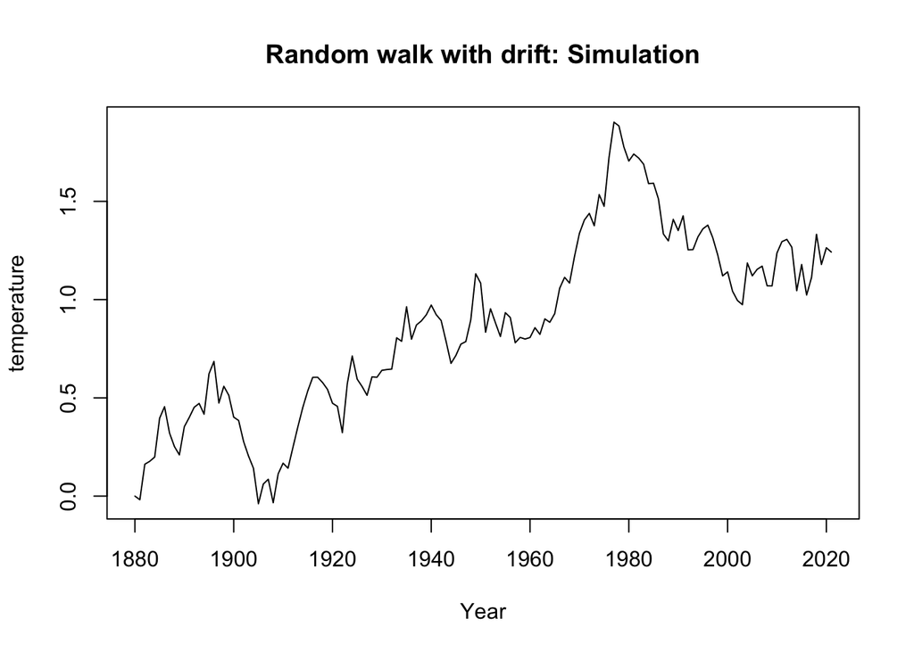

```r
set.seed(123)
N <- length(global$Annual)
w <- rnorm(N, mean = 0, sd = sd(diff(global$Annual), na.rm = TRUE))
y <- numeric(N)
for (n in 2:N) {
  y[n] <- y[n-1] + sigma + w[n]
}
plot(global$Year, y, type = "l", xlab = "Year", ylab = "temperature", main = "Random walk with drift: Simulation")
```

### discussion

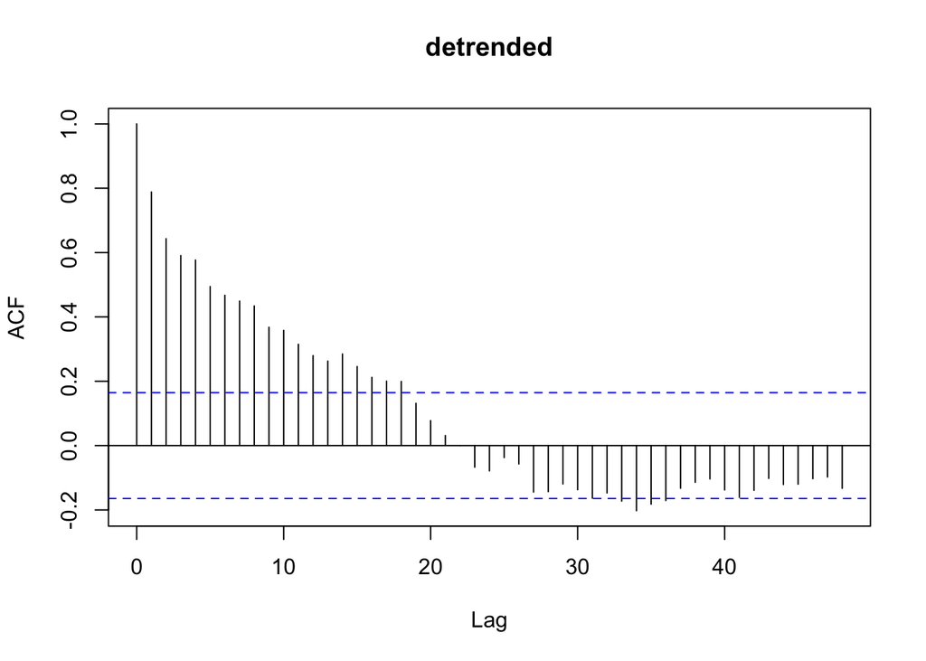

```r
acf(resid(fit)[!is.na(resid(fit))], 48, main = "detrended")
```

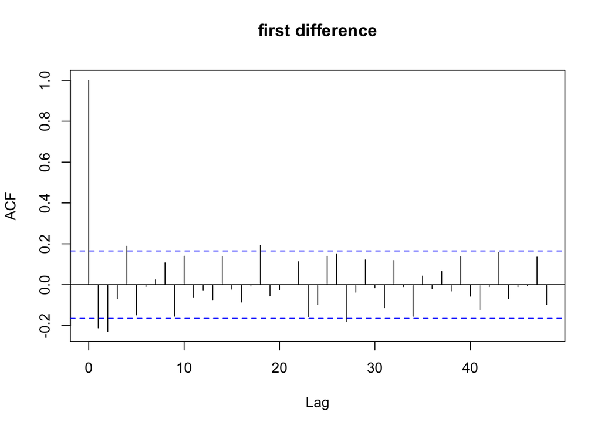

```r
acf(diff(global$Annual), 48, main = "first difference")
```

## 3. ARIMA

### model fitting

```r
gtemp <- global$Annual
temp_aic_table <- aic_table(gtemp,10,10)
require(knitr)
kable(temp_aic_table,digits=2)
```

|  | MA0 | MA1 | MA2 | MA3 | MA4 | MA5 | MA6 | MA7 | MA8 | MA9 | MA10 |
| --- | --- | --- | --- | --- | --- | --- | --- | --- | --- | --- | --- |
| AR0 | 118.37 | -8.29 | -90.75 | -112.59 | -137.95 | -156.08 | -161.54 | -166.75 | -180.40 | -180.80 | -193.19 |
| AR1 | -211.51 | NA | -229.56 | -230.31 | -229.55 | -227.70 | -226.14 | -224.68 | -224.09 | -224.71 | -222.83 |
| AR2 | -218.02 | -214.78 | -227.57 | -231.26 | -230.09 | -228.64 | -229.46 | -224.88 | -223.21 | -223.23 | -222.08 |
| AR3 | -226.57 | -228.83 | -226.32 | -229.84 | -227.45 | -226.75 | -223.32 | -228.09 | -223.62 | -223.77 | -219.33 |
| AR4 | -230.22 | -231.99 | -230.71 | -228.98 | -227.66 | -232.90 | -231.18 | -217.80 | -227.57 | -220.28 | -222.20 |
| AR5 | -229.01 | -230.54 | -229.11 | -227.01 | -226.63 | -231.24 | -228.46 | -224.29 | -224.12 | -218.97 | -216.14 |
| AR6 | -230.11 | -228.62 | -231.79 | -224.20 | -230.93 | -228.95 | -230.83 | -225.69 | -225.19 | -223.76 | -223.76 |
| AR7 | -228.22 | -226.12 | -228.49 | -223.58 | -228.94 | -226.79 | -226.97 | -230.49 | -223.65 | -221.75 | -223.94 |
| AR8 | -226.23 | -226.61 | -227.86 | -224.19 | -222.19 | -226.78 | -225.01 | -223.01 | -221.19 | -219.76 | -223.46 |
| AR9 | -225.35 | -225.67 | -224.13 | -225.54 | -226.61 | -224.99 | -222.99 | -220.65 | -218.41 | -223.51 | -225.28 |
| AR10 | -223.92 | -223.83 | -222.15 | -226.20 | -224.65 | -223.02 | -224.19 | -224.14 | -221.91 | -221.17 | -219.28 |

# Reference

1. [Homework3, DATASCI/STATS 531](https://ionides.github.io/531w24/hw03/hw03.html)
2. Shumway, R.H., and Stoffer, D.S., 2017. Time series analysis and its applications (4th edition). New York: Springer.
3. [wikipedia, OLS](https://en.wikipedia.org/wiki/Ordinary_least_squares#)
4. Julian J Faraway, 2014, Linear Models with R, Taylor & Francis
5. [Notes on random walk model](https://people.duke.edu/~rnau/Notes_on_the_random_walk_model--Robert_Nau.pdf)
6. [Autoregressive Moving-average Model](https://en.wikipedia.org/wiki/Autoregressive_moving-average_model#ARMA_model)
7. [Lecture Slides 5](https://ionides.github.io/531w24/05/slides.pdf)
8. [Lecture Slides 1, page 20](https://ionides.github.io/531w24/01/slides.pdf)